# Titanic_Analysis

2025-11-16

```r
library(readxl)
library(tidyverse)
library(ggridges)
library(PupillometryR)
library(Hmisc)
library(rms)
library(broom)
library(car)
```

```r
titanic3 <- read_excel("titanic3.xls")
titanic3
```

| pclass | survived | name | sex | age | sibsp | parch | ticket | fare | cabin | embarked | boat | body | home.dest |
| --- | --- | --- | --- | --- | --- | --- | --- | --- | --- | --- | --- | --- | --- |
| 1 | 1 | Allen, Miss. Elisabeth Walton | female | 29.0000 | 0 | 0 | 24160 | 211.3375 | B5 | S | 2 | NA | St Louis, MO |
| 1 | 1 | Allison, Master. Hudson Trevor | male | 0.9167 | 1 | 2 | 113781 | 151.5500 | C22 C26 | S | 11 | NA | Montreal, PQ / Chesterville, ON |
| 1 | 0 | Allison, Miss. Helen Loraine | female | 2.0000 | 1 | 2 | 113781 | 151.5500 | C22 C26 | S | NA | NA | Montreal, PQ / Chesterville, ON |
| 1 | 0 | Allison, Mr. Hudson Joshua Creighton | male | 30.0000 | 1 | 2 | 113781 | 151.5500 | C22 C26 | S | NA | 135 | Montreal, PQ / Chesterville, ON |
| 1 | 0 | Allison, Mrs. Hudson J C (Bessie Waldo Daniels) | female | 25.0000 | 1 | 2 | 113781 | 151.5500 | C22 C26 | S | NA | NA | Montreal, PQ / Chesterville, ON |
| 1 | 1 | Anderson, Mr. Harry | male | 48.0000 | 0 | 0 | 19952 | 26.5500 | E12 | S | 3 | NA | New York, NY |
| 1 | 1 | Andrews, Miss. Kornelia Theodosia | female | 63.0000 | 1 | 0 | 13502 | 77.9583 | D7 | S | 10 | NA | Hudson, NY |
| 1 | 0 | Andrews, Mr. Thomas Jr | male | 39.0000 | 0 | 0 | 112050 | 0.0000 | A36 | S | NA | NA | Belfast, NI |
| 1 | 1 | Appleton, Mrs. Edward Dale (Charlotte Lamson) | female | 53.0000 | 2 | 0 | 11769 | 51.4792 | C101 | S | D | NA | Bayside, Queens, NY |
| 1 | 0 | Artagaveytia, Mr. Ramon | male | 71.0000 | 0 | 0 | PC 17609 | 49.5042 | NA | C | NA | 22 | Montevideo, Uruguay |

[output cut: 1299 more lines]

```r
titanic3$survived <-as.factor(titanic3$survived)
titanic3$pclass <-as.factor(titanic3$pclass)
titanic3$embarked <-as.factor(titanic3$embarked)
```

## 0.1 Titanic survial rate

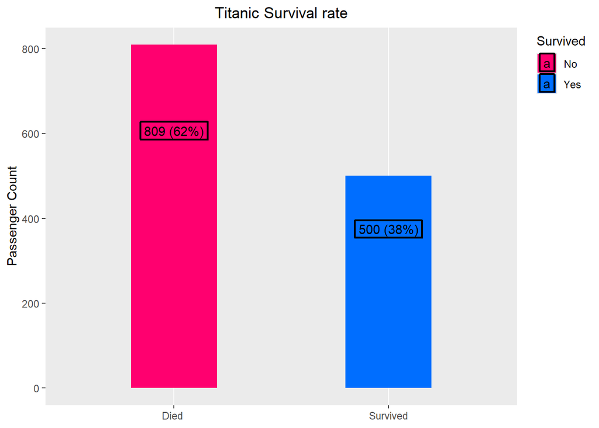

```r
titanic3 %>% group_by(survived) %>% summarise(count=n()) %>% mutate(percentage=count/sum(count)*100) %>%
  ggplot(aes(x = survived,y=count,fill=survived))+
  geom_col(width = 0.4) + scale_fill_manual(values = c("#ff006f", "#006eff"), name = "Survived",labels = c("No", "Yes")) +scale_x_discrete(labels=c("0" = "Died ", "1" = "Survived")) + theme(legend.justification = c("right", "top"),plot.title = element_text(hjust = 0.5),panel.grid.major.y = element_blank(),panel.grid.minor.y = element_blank()) + labs(title = "Titanic Survival rate",x=NULL,y="Passenger Count")+ geom_label(aes(label = paste0(count, " (", round(percentage), "%)"),y=count),label.padding = unit(0.25, "lines"),label.size = 0.75,label.r = unit(0.005, "lines"),
            position = position_stack(vjust = 0.75))
```

## 0.2 Conclusions:

- The analysis of the data from the Titanic shows that the number of deaths was greater than the number of survivors.

## 0.3 Titanic survival rate by gender

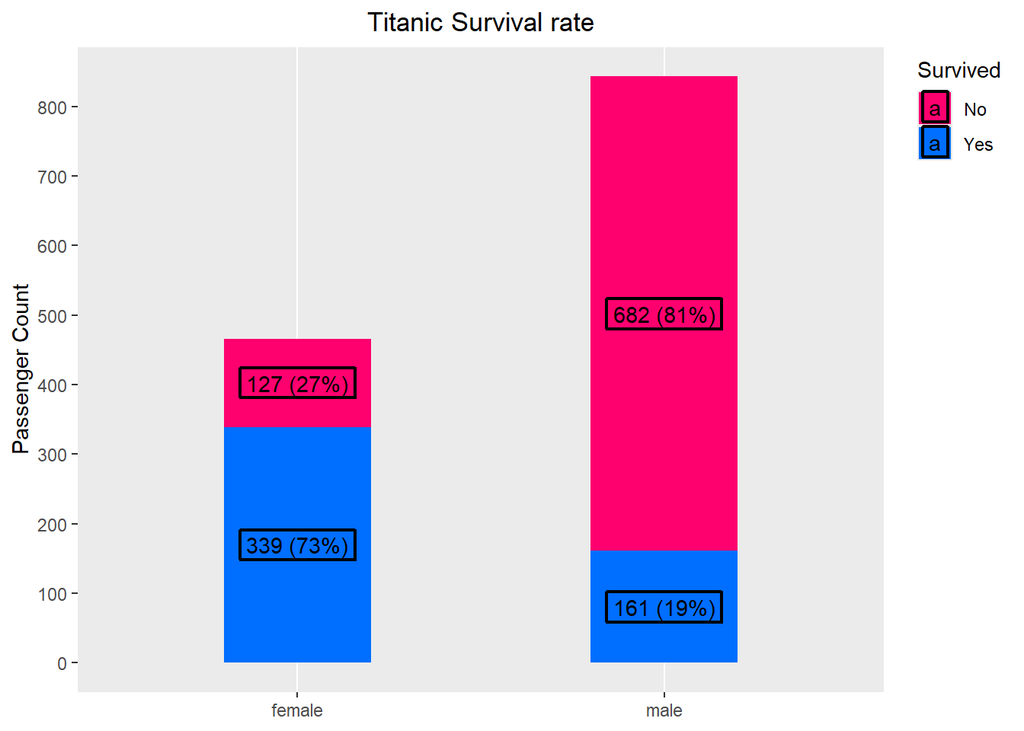

```r
titanic3 %>%
  group_by(survived,sex) %>%
  summarise(count=n()) %>%
  ungroup() %>%
  group_by(sex) %>%
  mutate(total_count = sum(count)) %>%
  mutate(survival_rate = count / total_count * 100) %>%
  mutate(percentage=count/sum(count)*100) %>%
  ggplot(aes(x = sex,y=count,fill = survived)) +
  geom_bar(width = 0.4,stat="identity") +
  scale_fill_manual(values = c("#ff006f", "#006eff"),
                    name = "Survived",
                    labels = c("No", "Yes")) +
  scale_x_discrete(labels=c("0" = "Died ", "1" = "Survived")) +
  theme(legend.justification = c("right", "top"),
        plot.title = element_text(hjust = 0.5),
        panel.grid.major.y =element_blank(),
        panel.grid.minor.y = element_blank()) +
  labs(title = "Titanic Survival rate",x=NULL,y="Passenger Count") +
  geom_label(aes(label = paste0(count, " (", round(survival_rate), "%)"),y=count),
             label.padding = unit(0.25, "lines"),
             label.size = 0.75,
             label.r = unit(0.005, "lines"),
            position = position_stack(vjust = 0.5)) +
  scale_y_continuous(breaks=c(0,100,200,300,400,500,600,700,800))
```

## 0.4 **Conclusion** :

- The data indicates that male passengers outweight female passengers on the Titanic, and the death rate for male passengers was higher than that of female passengers

## 0.5 Titanic survival rate by class

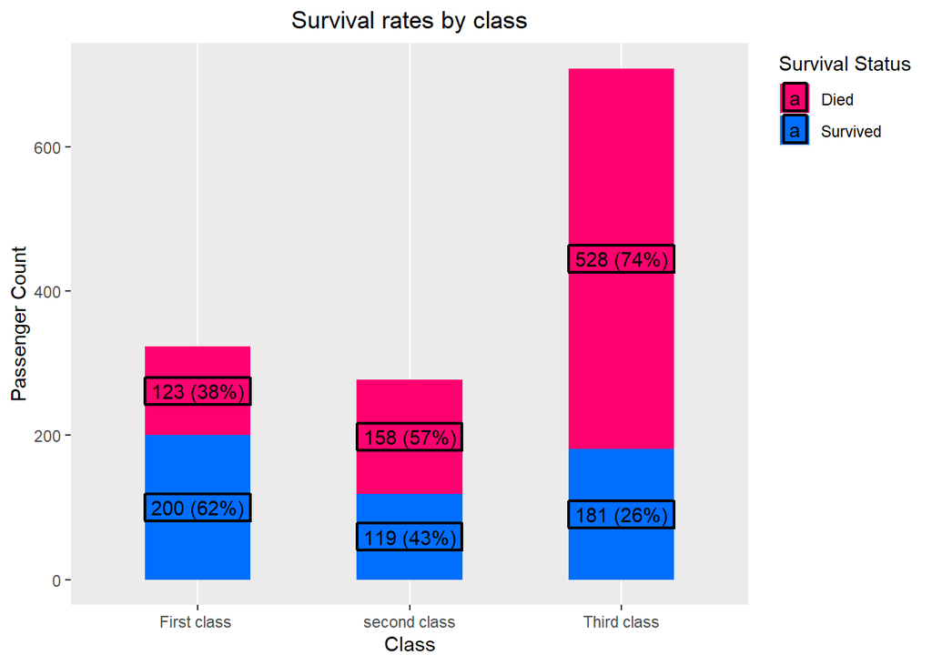

```r
titanic3 %>%
  group_by(survived,pclass) %>%
  summarise(count=n()) %>%
  ungroup() %>%
  group_by(pclass) %>%
  mutate(total_count = sum(count)) %>%
  mutate(survival_rate = count / total_count * 100) %>%
  ggplot(aes(x = pclass,y= count, fill = survived)) +
  geom_bar(width = 0.5,stat = "identity") +
  scale_fill_manual(values= c("#ff006f", "#006eff"), name = "Survival Status", labels = c("Died", "Survived")) +
  theme(legend.justification = c("right", "top"),plot.title = element_text(hjust = 0.5),panel.grid.major.y = element_blank(),
  panel.grid.minor.y = element_blank()) +
  labs(title = "Survival rates by class",x="Class",y="Passenger Count")+
  geom_label(aes(label = paste0(count, " (", round(survival_rate), "%)"),y=count),
             label.padding = unit(0.25, "lines"),
             label.size = 0.75,
             label.r = unit(0.005, "lines"),
            position = position_stack(vjust = 0.5))+
  scale_x_discrete(labels=c("1" = "First class ", "2" = "second class","3"="Third class"))
```

## 0.6 Titanic survival rate by class and gender

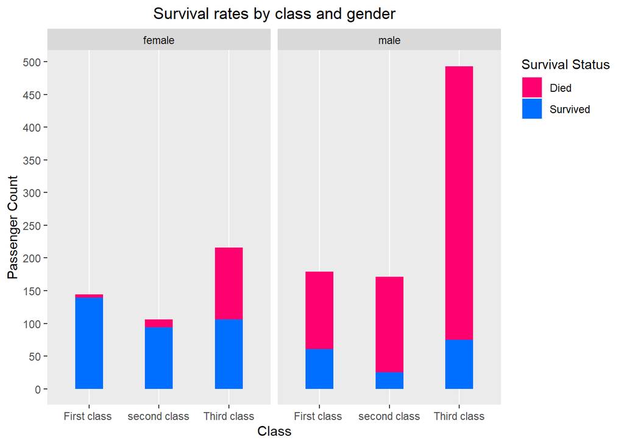

```r
titanic3 %>%
  ggplot(aes(x = pclass, fill = survived)) +
  geom_bar(width = 0.4) +
  scale_fill_manual(values= c("#ff006f", "#006eff"), name = "Survival Status", labels = c("Died", "Survived")) +
  theme(legend.justification = c("right", "top"),plot.title = element_text(hjust = 0.5),panel.grid.major.y = element_blank(),
  panel.grid.minor.y = element_blank()) +
  labs(title = "Survival rates by class and gender",x="Class",y="Passenger Count")+
  scale_y_continuous(breaks=c(0,50,100,150,200,250,300,350,400,450,500,550,600,650,700))+
  scale_x_discrete(labels=c("1" = "First class ", "2" = "second class","3"="Third class"))+ facet_grid(~sex)
```

## 0.7 **conclusion** :

- The data suggests that the third class had the highest death rate compared to the other classes while the first class had the highest survival rate.
- The death rate in males was higher in the Three classes

## 0.8 Age range and survival using boxplot

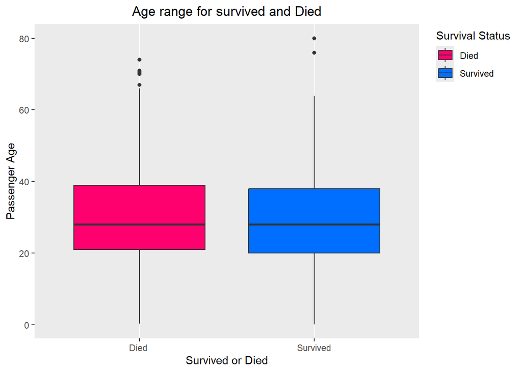

```r
Age_Plot_Box <- ggplot(titanic3,aes(y=age,x=survived,fill=survived)) + geom_boxplot() + scale_fill_manual(values = c("#ff006f", "#006eff"),name = "Survival Status", labels = c("Died", "Survived")) +
  ggtitle("Age range for survived and Died")+ labs(x="Survived or Died",y="Passenger Age") +
scale_x_discrete(labels=c("0" = "Died ", "1" = "Survived"))+ theme(legend.justification = c("right", "top"),plot.title = element_text(hjust = 0.5),panel.grid.major.y = element_blank(),
    panel.grid.minor.y = element_blank())
Age_Plot_Box
```

# 1 Age range and survival rate using violin plot

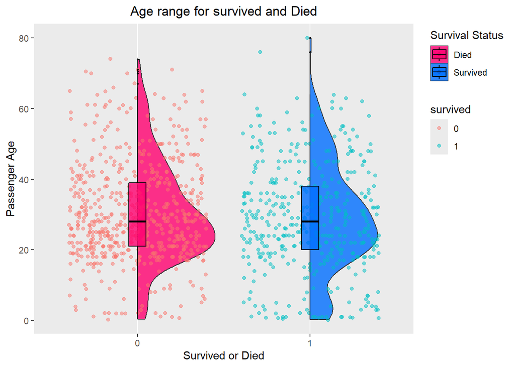

```r
Age_Plot <- ggplot(titanic3, aes(x = survived, y = age, fill = survived)) +
  geom_flat_violin(alpha = 0.8) +
  geom_point(aes(color = survived), position = position_jitter(height = 0.1), alpha = 0.5, size = 1.5) +
  geom_boxplot(width = 0.1, alpha = 0.8, color = "black", size = 0.5) +
  scale_fill_manual(values = c("#ff006f", "#006eff"), name = "Survival Status", labels = c("Died", "Survived")) +
  ggtitle("Age range for survived and Died") +
  labs(x = "Survived or Died", y = "Passenger Age") +
  theme(legend.justification = c("right", "top"), plot.title = element_text(hjust = 0.5), panel.grid.major.y = element_blank(), panel.grid.minor.y = element_blank())
Age_Plot
```

# 2 Age range using histogram

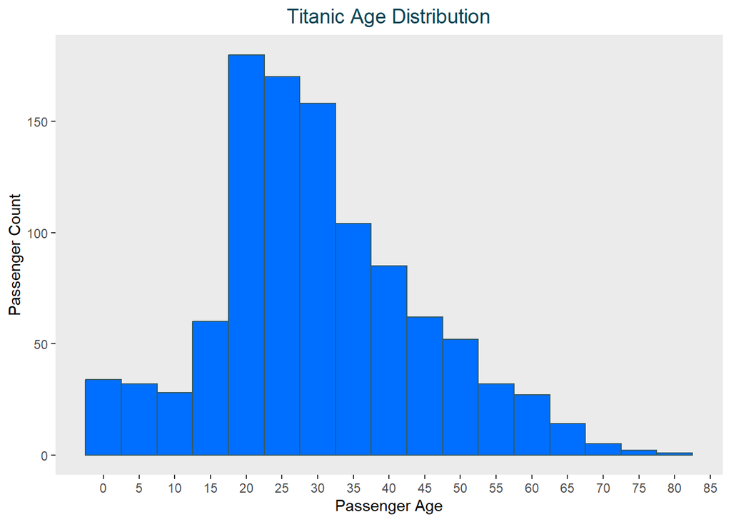

```r
titanic3 %>%
  ggplot() +
  geom_histogram(aes(x = age), binwidth = 5, color = "#355a63", fill = "#006eff") +
  theme(plot.title = element_text(hjust = 0.5, size=14, color = "#054354"),panel.grid.major.x = element_blank(),
    panel.grid.minor.x = element_blank(),panel.grid.major.y = element_blank(),
    panel.grid.minor.y = element_blank()) +
  ggtitle("Titanic Age Distribution") +
  scale_x_continuous(name= "Passenger Age", breaks = 5*c(0:18)) +
  scale_y_continuous(name = "Passenger Count")
```

# 3 Age range and Survival using histogram

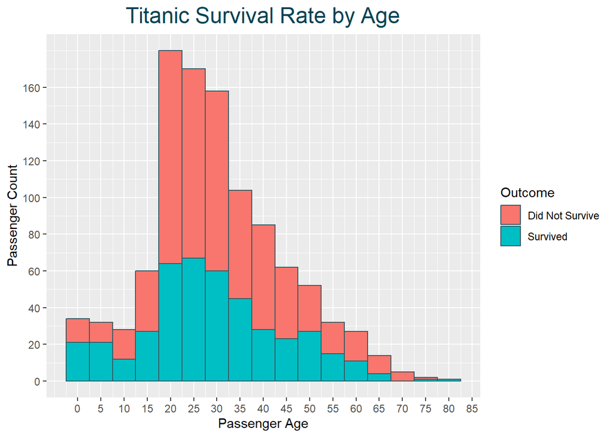

```r
titanic3 %>%
  ggplot() +
  geom_histogram(aes(x = age, fill = survived), binwidth = 5, color = "#355a63") +
  theme(plot.title = element_text(hjust = 0.5, size=18, color = "#054354")) +
  ggtitle("Titanic Survival Rate by Age") +
  scale_x_continuous(name= "Passenger Age", breaks = 5*c(0:18)) +
  scale_y_continuous(name = "Passenger Count",breaks = c(0,20,40,60,80,100,120,140,160)) +
  scale_fill_discrete(name = "Outcome", labels = c("Did Not Survive", "Survived"))
```

# 4 Survival rates by age and gender Using Histogram

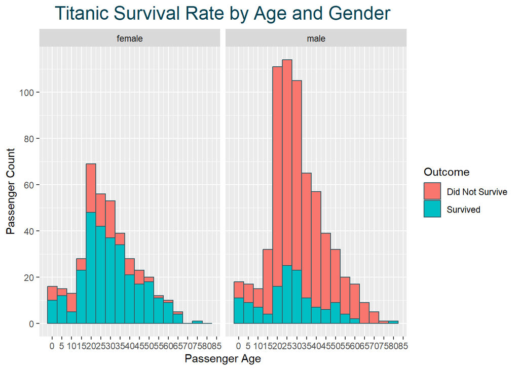

```r
titanic3 %>%
  ggplot() +
  geom_histogram(aes(x = age, fill = survived), binwidth = 5, color = "#355a63") +
  theme(plot.title = element_text(hjust = 0.5, size=18, color = "#054354")) +
  ggtitle("Titanic Survival Rate by Age and Gender") +
  scale_x_continuous(name= "Passenger Age", breaks = 5*c(0:18)) +
  scale_y_continuous(name = "Passenger Count",breaks = c(0,20,40,60,80,100,120,140,160)) +
  scale_fill_discrete(name = "Outcome", labels = c("Did Not Survive", "Survived")) +facet_wrap(~sex,dir="v")
```

## 4.1 *Conclusion* :

- Age range is between 20-40 old
- Mostly all females range 50 and above survived while most males age 50 and above dies
- nearly half of the males less than 10 years old survived, At 15 years old most of the males didn’t survive

# 5 Trying stripplot to visualize age range versus embarked or not

- Leh fe nas ta7t el sefr ?
- Fe 3 patients 80s in south not in the data set

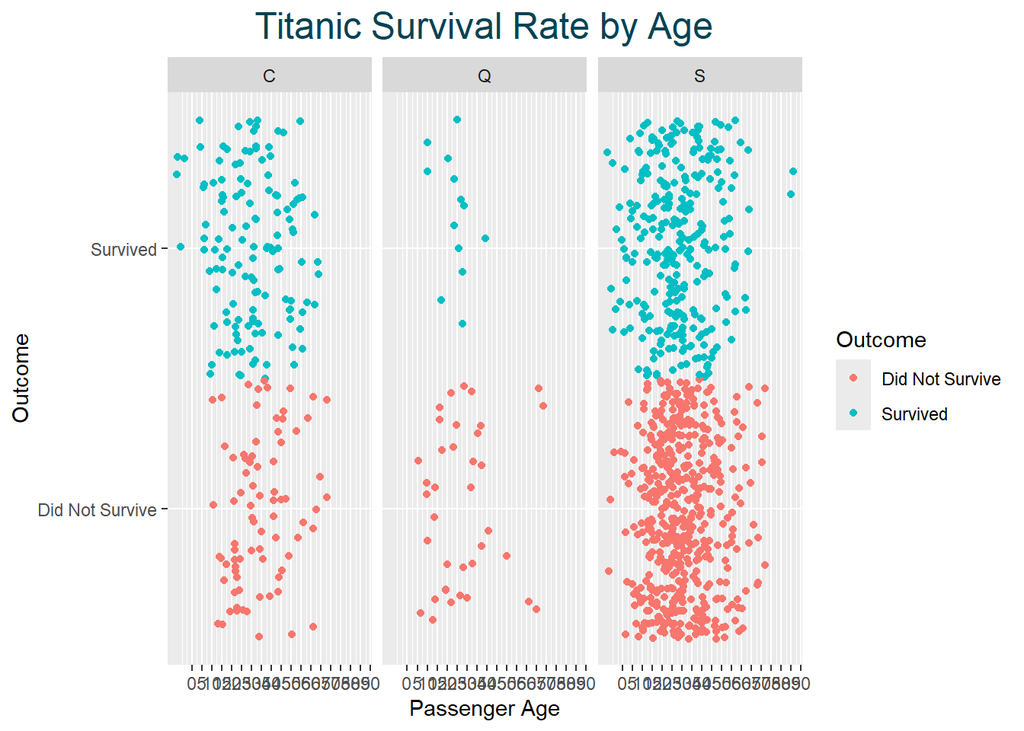

```r
titanic3 %>%
  filter(embarked != "") %>%
  ggplot() +
  geom_jitter(aes(x = age, y = factor(survived), color = factor(survived)), width = 10, height = 0.5) +
  theme(plot.title = element_text(hjust = 0.5, size=18, color = "#054354")) +
  ggtitle("Titanic Survival Rate by Age") +
  scale_x_continuous(name= "Passenger Age", breaks = 5*c(0:18)) +
  scale_y_discrete(name = "Outcome", labels = c("Did Not Survive", "Survived")) +
  scale_color_discrete(name = "Outcome", labels = c("Did Not Survive", "Survived"))+ facet_wrap(~embarked,dir="v")
```

## 5.1 Survival across age ranges using density plot

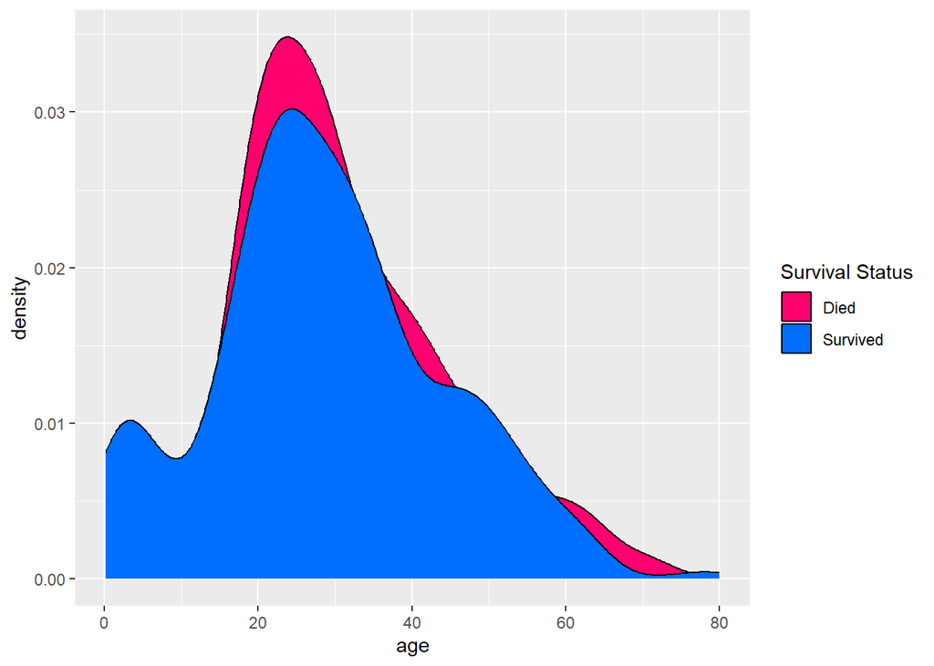

```r
titanic3 %>%
  ggplot() +
  geom_density(aes(x=age,fill=survived)) +
  scale_fill_manual(values= c("#ff006f", "#006eff"), name = "Survival Status", labels = c("Died", "Survived"))
```

```r
  theme(plot.title = element_text(hjust = 0.5, size=14, color = "#054354"),panel.grid.major.x = element_blank(),
  panel.grid.minor.x = element_blank(),panel.grid.major.y = element_blank(),
  panel.grid.minor.y = element_blank()) +
  ggtitle("Titanic Age Distribution")
```

[output not shown]

## 5.2 Survival rate by embarking and age

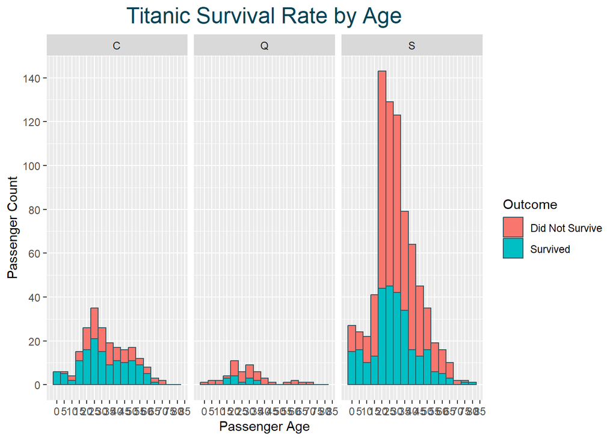

```r
titanic3 %>%
  filter(embarked != "") %>%
  ggplot() +
  geom_histogram(aes(x = age, fill = survived), binwidth = 5, color = "#355a63") +
  theme(plot.title = element_text(hjust = 0.5, size=18, color = "#054354")) +
  ggtitle("Titanic Survival Rate by Age") +
  scale_x_continuous(name= "Passenger Age", breaks = 5*c(0:18)) +
  scale_y_continuous(name = "Passenger Count",breaks = c(0,20,40,60,80,100,120,140,160)) +
  scale_fill_discrete(name = "Outcome", labels = c("Did Not Survive", "Survived"))+facet_wrap(~embarked,dir = "v")
```

## 5.3 Survival rates by embarking places

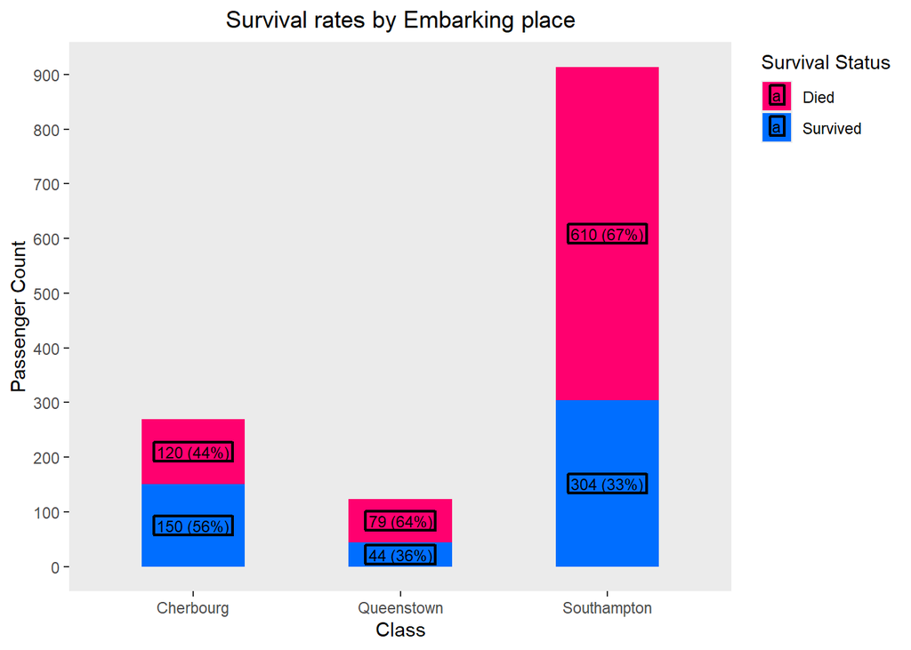

```r
titanic3 %>%
  filter(embarked != "") %>%
  group_by(survived,embarked) %>%
  summarise(count=n()) %>%
  mutate(percentage=count/sum(count)*100) %>%
  ungroup() %>%
  group_by(embarked) %>%
  mutate(total_count = sum(count)) %>%
  mutate(survival_rate = count / total_count * 100) %>%
  ggplot(aes(x = embarked,y=count, fill = survived)) +
  geom_bar(width = 0.5,stat = "identity") +
  scale_fill_manual(values= c("#ff006f", "#006eff"), name = "Survival Status", labels = c("Died", "Survived")) +
  theme(legend.justification = c("right", "top"),plot.title = element_text(hjust = 0.5),panel.grid.major.x = element_blank(),
  panel.grid.minor.x = element_blank(),panel.grid.major.y = element_blank(),
  panel.grid.minor.y = element_blank()) +
  labs(title = "Survival rates by Embarking place",x="Class",y="Passenger Count")+
  scale_y_continuous(breaks=c(0,100,200,300,400,500,600,700,800,900))+
  scale_x_discrete(labels=c("C" = "Cherbourg", "Q" = "Queenstown","S"="Southampton"))+
  geom_label(aes(label = paste0(count, " (", round(survival_rate), "%)"),y=count,group= survived),
             label.padding = unit(0.15, "lines"),
             label.size = 0.75,
             label.r = unit(0.005, "lines"),
            position = position_stack(vjust = 0.5),size=3)
```

## 5.4 Survival rate by sex and embarking place

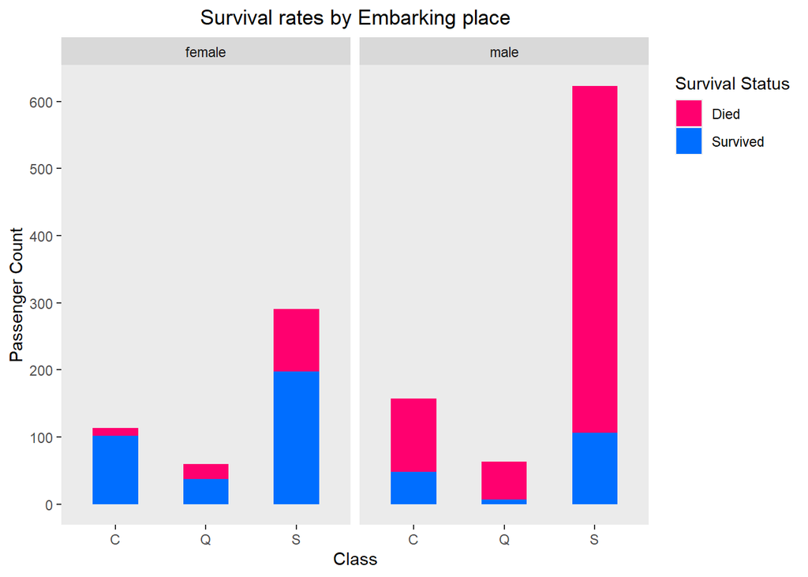

```r
titanic3 %>%
  filter(embarked != "") %>%
  group_by(sex, embarked, survived) %>%
  summarise(count = n()) %>%
  ggplot(aes(x = embarked, y = count, fill = survived)) +
  geom_bar(width = 0.5, stat = "identity") +
  scale_fill_manual(values = c("#ff006f", "#006eff"), name = "Survival Status", labels = c("Died", "Survived")) +
  theme(legend.justification = c("right", "top"), plot.title = element_text(hjust = 0.5), panel.grid.major.x = element_blank(),
        panel.grid.minor.x = element_blank(), panel.grid.major.y = element_blank(),
        panel.grid.minor.y = element_blank()) +
  labs(title = "Survival rates by Embarking place", x = "Class", y = "Passenger Count") +
  scale_y_continuous(breaks = c(0, 100, 200, 300, 400, 500, 600, 700, 800, 900)) +
  facet_wrap(~ sex)
```

## 5.5 Survival rate by sex and siblings/spouses

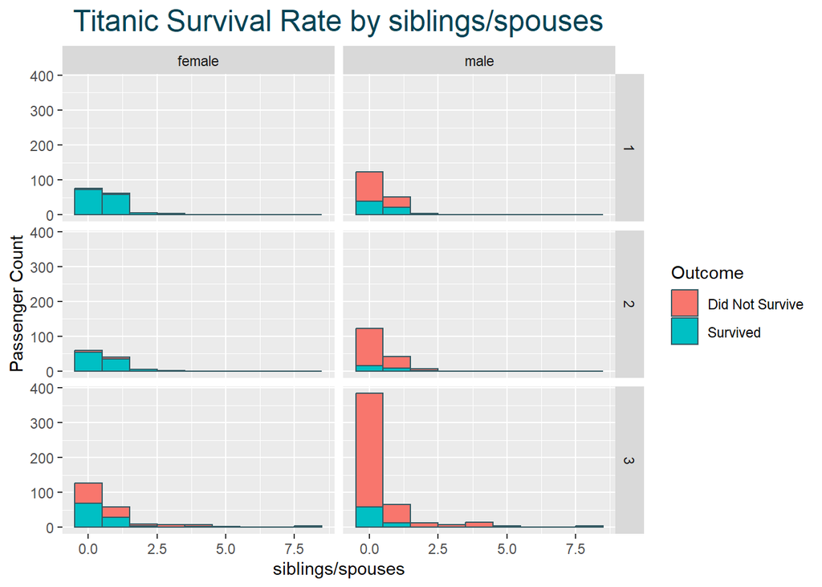

```r
titanic3 %>%
  ggplot() +
  geom_histogram(aes(x =sibsp , fill = as.factor(survived)), binwidth = 1,color = "#355a63") +
  facet_grid(pclass ~ sex) +
  theme(plot.title = element_text(hjust = 0.5, size=18, color = "#054354")) +
  xlim(0,9)+
  scale_fill_manual(values = c("#ff006f", "#006eff"))+
  ggtitle("Titanic Survival Rate by siblings/spouses") +
  scale_x_continuous(name = "siblings/spouses") +
  scale_y_continuous(name = "Passenger Count") +
  scale_fill_discrete(name = "Outcome", labels = c("Did Not Survive", "Survived"))
```

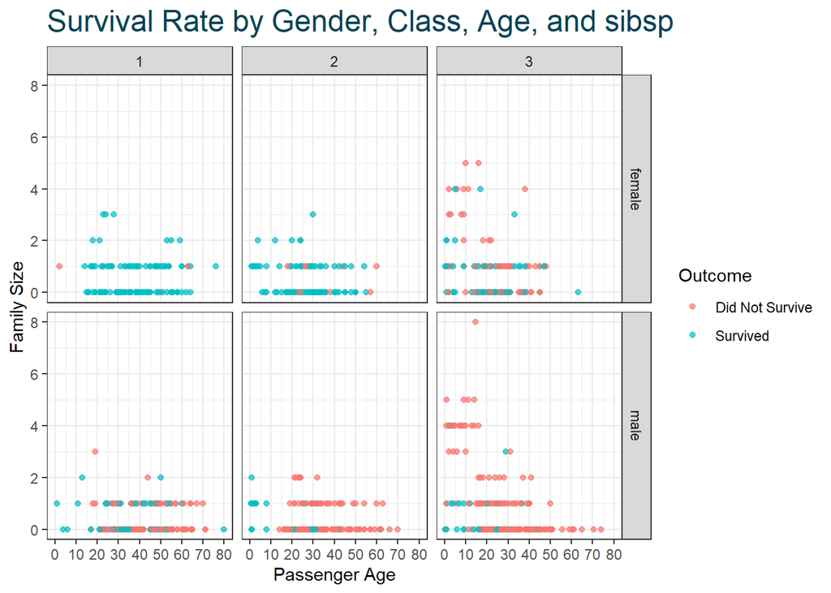

```r
titanic3 %>%
  ggplot() +
  geom_point(aes(x = age, y = sibsp, color = as.factor(survived)), alpha = 0.7) +
  facet_grid(sex ~ pclass) +
  theme_bw() +
  theme(plot.title = element_text(size=18, color = "#054354")) +
  ggtitle("Survival Rate by Gender, Class, Age, and sibsp") +
  scale_x_continuous(name= "Passenger Age", breaks = 10*c(0:8)) +
  scale_y_continuous(name = "Family Size") +
  scale_color_discrete(name = "Outcome", labels = c("Did Not Survive", "Survived"))
```

## 5.6 **conclusions** :

- almost all females with zero/one sibling/spouse survived while most of the males died in the first class and second class
- 7/8 of the males who have zero siblings have died in the third class while half of the females died in the third class
- Majority of Males and Females in 3rd Pclass with Sib/spouse of 5 and above Did Not Survive

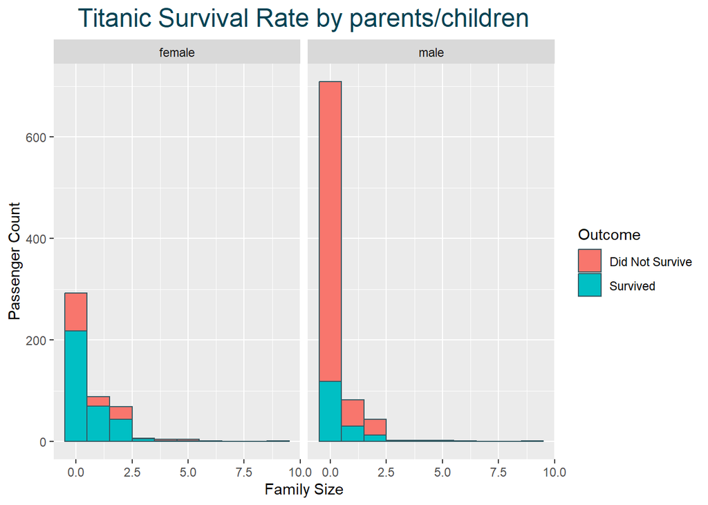

```r
titanic3 %>%
  ggplot() +
  geom_histogram(aes(x =parch , fill = as.factor(survived)), binwidth = 1,color = "#355a63") +
  facet_grid(~ sex) +
  theme(plot.title = element_text(hjust = 0.5, size=18, color = "#054354")) +
  scale_fill_manual(values = c("#ff006f", "#006eff"))+
  ggtitle("Titanic Survival Rate by parents/children") +
  scale_x_continuous(name = "Family Size") +
  scale_y_continuous(name = "Passenger Count") +
  scale_fill_discrete(name = "Outcome", labels = c("Did Not Survive", "Survived"))
```

```r
titanic3 %>% select(survived,sibsp) %>% group_by(as.factor(survived),sibsp) %>% count()
```

| as.factor(survived) | sibsp | n |
| --- | --- | --- |
| 0 | 0 | 582 |
| 0 | 1 | 156 |
| 0 | 2 | 23 |
| 0 | 3 | 14 |
| 0 | 4 | 19 |
| 0 | 5 | 6 |
| 0 | 8 | 9 |
| 1 | 0 | 309 |
| 1 | 1 | 163 |
| 1 | 2 | 19 |

[output cut: 2 more lines]

```r
p2_2 <- ggplot(titanic3, aes(x = age, y = survived, color = cut2(sibsp,
       0:2))) +
  geom_point() +  # Add points to the plot
  geom_smooth(method = "loess", se = FALSE) +  # Fit a loess curve
  ylim(0, 1) +  # Set the y-axis limits
  ylab("Survived")
```

```r
titanic3 <- read_excel("titanic3.xls")
b  <- scale_size_discrete(range=c(.1, .85))
yl <- ylab(NULL)
titanic3 %>% select(survived,parch) %>% group_by(as.factor(survived),parch) %>% count()
```

| as.factor(survived) | parch | n |
| --- | --- | --- |
| 0 | 0 | 666 |
| 0 | 1 | 70 |
| 0 | 2 | 56 |
| 0 | 3 | 3 |
| 0 | 4 | 5 |
| 0 | 5 | 5 |
| 0 | 6 | 2 |
| 0 | 9 | 2 |
| 1 | 0 | 336 |
| 1 | 1 | 100 |

[output cut: 4 more lines]

```r
titanic3 %>% select(survived,sex,parch) %>% group_by(as.factor(survived),sex,parch) %>% count()
```

| as.factor(survived) | sex | parch | n |
| --- | --- | --- | --- |
| 0 | female | 0 | 75 |
| 0 | female | 1 | 18 |
| 0 | female | 2 | 25 |
| 0 | female | 3 | 1 |
| 0 | female | 4 | 3 |
| 0 | female | 5 | 3 |
| 0 | female | 6 | 1 |
| 0 | female | 9 | 1 |
| 0 | male | 0 | 591 |
| 0 | male | 1 | 52 |

[output cut: 15 more lines]

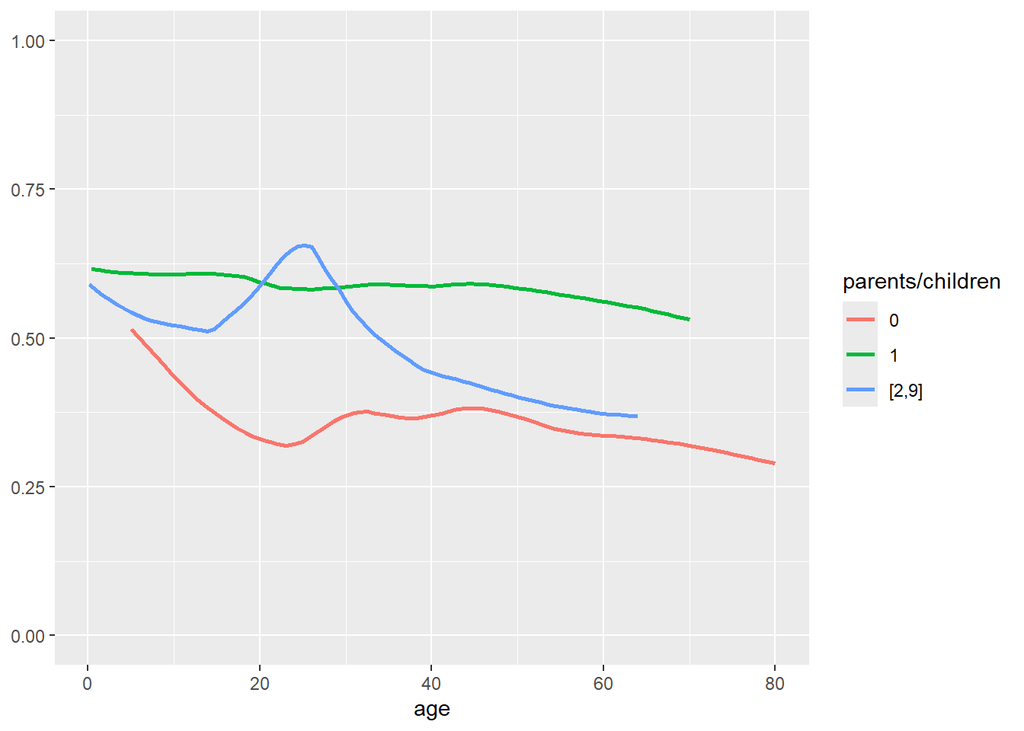

```r
p2_2 <- ggplot(titanic3, aes(x=age, y=survived, color=cut2(parch,
       0:2))) + stat_plsmo() + b + ylim(0,1) + yl +
      scale_color_discrete(name='parents/children')
p2_2
```

## **conclusion** : * people with zero parents and childen has 0.5 probability survival if less than 10 years while it reached 0.3 in years more than 20 * people with one parent/child had more than 0.5 probability survival across the ages * for people with 2 or more par/child probability survival peaked at age 20 - 40 to be more than 0.6

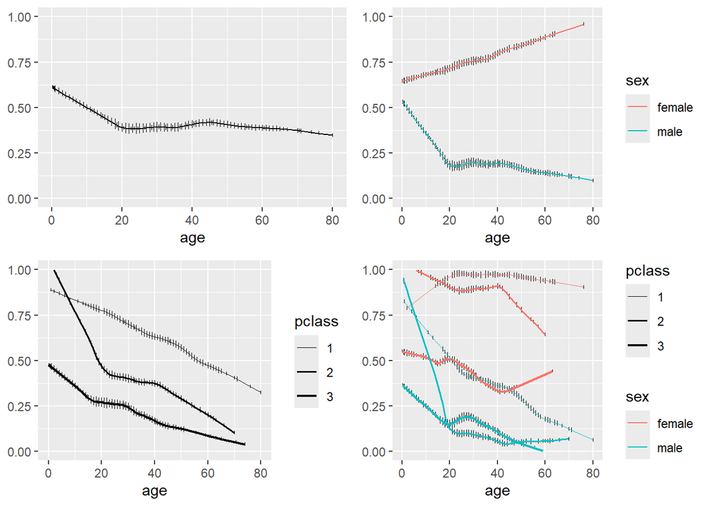

```r
titanic3 <- read_excel("titanic3.xls")
b  <- scale_size_discrete(range=c(.1, .85))
yl <- ylab(NULL)
p1 <- ggplot(titanic3, aes(x=age, y=survived)) +
      histSpikeg(survived ~ age, lowess=TRUE, data=titanic3) +
      ylim(0,1)+yl

p2 <- ggplot(titanic3, aes(x=age, y=as.numeric(survived), color=sex)) +
      histSpikeg(survived ~ age + sex, lowess=TRUE,
                 data=titanic3) + ylim(0,1) +yl
p3 <- ggplot(titanic3, aes(x=age, y=as.numeric(survived), size=pclass)) +
      histSpikeg(survived ~ age + pclass, lowess=TRUE,
                 data=titanic3) + ylim(0,1) +b +yl
p4 <- ggplot(titanic3, aes(x=age, y=as.numeric(survived), color=sex,
       size=pclass)) +
      histSpikeg(survived ~ age + sex + pclass,
                 lowess=TRUE, data=titanic3) +ylim(0,1)+b +yl
Plot_age_sex_class <-gridExtra::grid.arrange(p1, p2, p3, p4, ncol=2)
```

```r
Plot_age_sex_class
```

## 5.7 **conclusions** :

- female survival probability is very high under20 years the probability is 1 for second class decreased to 0.85 till 40 years while above 40 years probability decreased till it reached 0.6
- female survival probability is near 1 till for first class from 20 to 75 years while under 20 nearly 0.8 for class 3 probability of survival is above 0.5 rill 15 years then dicrease to 0.3 at 40 years

# 6 Checking regression assumptions

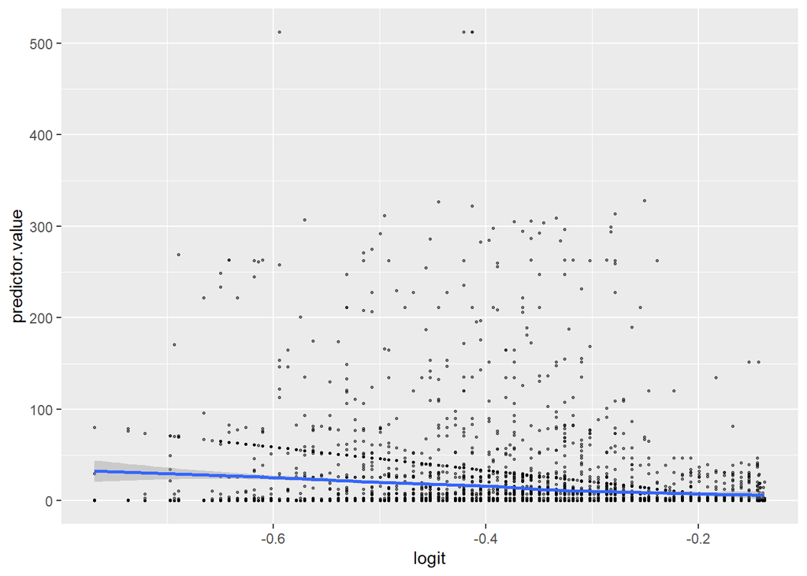

```r
model <- glm(as.factor(survived) ~ as.numeric(age), data = titanic3,
               family = binomial)
probabilities <- predict(model, type = "response")
mydata <- titanic3 %>%
  dplyr::select_if(is.numeric)
test <- mydata %>% filter(!is.na(age)) %>%
  mutate(logit = log(probabilities/(1-probabilities))) %>%
  gather(key = "predictors", value = "predictor.value", -logit)

ggplot(test, aes(logit, predictor.value))+
  geom_point(size = 0.5, alpha = 0.5) +
  geom_smooth(method = "loess")
```

# 7 cook distance

## 7.1 Influential values are extreme individual data points that can alter the quality of the logistic regression model.

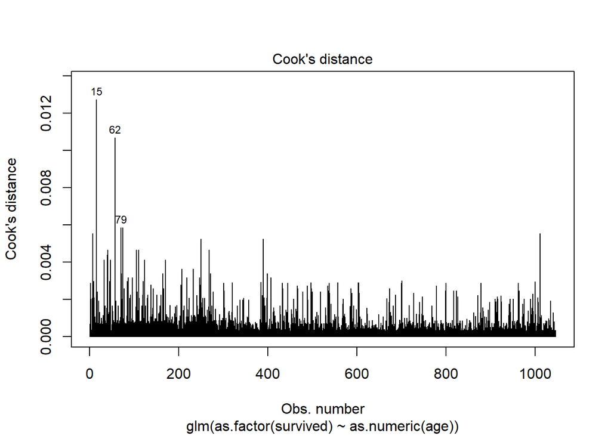

```r
plot(model, which = 4, id.n = 3)
```

```r
model.data <- augment(model) %>%
 mutate(index = 1:n())
 model.data %>% top_n(3, .cooksd)
```

| .rownames | as.factor(survived) | as.numeric(age) | .fitted | .resid | .hat | .sigma | .cooksd | .std.resid | index |
| --- | --- | --- | --- | --- | --- | --- | --- | --- | --- |
| 15 | 1 | 80 | -0.7684191 | 1.516191 | 0.011549636 | 1.162310 | 0.01274526 | 1.525023 | 15 |
| 62 | 1 | 76 | -0.7368247 | 1.501960 | 0.010034480 | 1.162330 | 0.01069606 | 1.509553 | 57 |
| 79 | 1 | 64 | -0.6420415 | 1.459338 | 0.006098078 | 1.162386 | 0.00586558 | 1.463808 | 71 |
| 84 | 1 | 64 | -0.6420415 | 1.459338 | 0.006098078 | 1.162386 | 0.00586558 | 1.463808 | 75 |

```r
 model.data %>%
 filter(abs(.std.resid) > 3)
```

| .rownames | as.factor(survived) | as.numeric(age) | .fitted | .resid | .hat | .sigma | .cooksd | .std.resid | index |
| --- | --- | --- | --- | --- | --- | --- | --- | --- | --- |